# Deep Neural Networks: Bank Churn prediction

### Model Building: Neural Network model with Adam Optimizer

```python
backend.clear_session()
# Fixing the seed for random number generators so that we can ensure we receive the same output everytime
np.random.seed(1)
random.seed(1)
tf.random.set_seed(1)
```

```python
def create_model():
    ## Initializing the neural network
    model = Sequential()

    ## 64 neurons and relu as activation function
    model.add(Dense(64, activation="relu", input_dim=14))

    ## 32 neurons with relu as activation functions
    model.add(Dense(32, activation="relu"))

    ## Complete the code to add the output layer with Sigmoid Activation
    model.add(Dense(1, activation="sigmoid"))

    ## Complete the code to initialize the model with Adam Optimer
    opt = tf.keras.optimizers.Adam(0.001)

    ## Complete the code to compile the model with binary cross entropy as loss function and accuracy as metrics
    model.compile(loss="binary_crossentropy", optimizer=opt, metrics=["accuracy"])
    return model
```

```python
model2 = create_model()
model2.summary()
```

```
Model: "sequential"
_________________________________________________________________
 Layer (type)                Output Shape              Param #
=================================================================
 dense (Dense)               (None, 64)                960

 dense_1 (Dense)             (None, 32)                2080

 dense_2 (Dense)             (None, 1)                 33

=================================================================
Total params: 3,073
Trainable params: 3,073
Non-trainable params: 0
_________________________________________________________________
```

```python
## Fitting the model on train data
history2 = model2.fit(
    X_train,
    y_train,
    batch_size=32,
    validation_data=(X_val, y_val),
    epochs=100,
    verbose=1,
)
```

**Loss function**

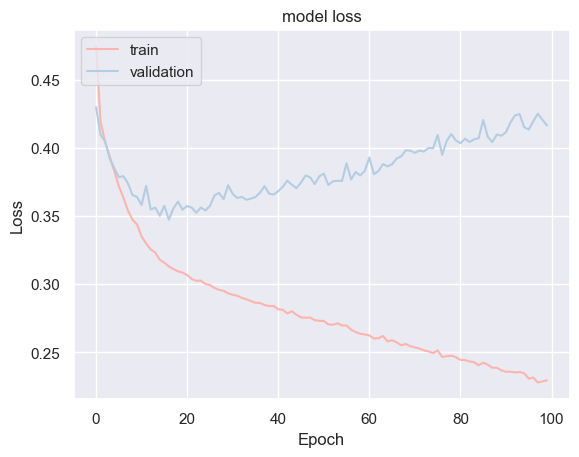

```python
# Plotting Train Loss vs Validation Loss
plt.plot(history2.history["loss"])
plt.plot(history2.history["val_loss"])
plt.title("model loss")
plt.ylabel("Loss")
plt.xlabel("Epoch")
plt.legend(["train", "validation"], loc="upper left")
plt.show()
```

**Using Early stopping:**

```python
# Defining Early stopping
es_cb = callbacks.EarlyStopping(monitor="val_loss", min_delta=0.001, patience=5)

## Call the create_model() function
model_es = create_model()

## Train the model on X_train and y_train for 100 epochs and also use X_val and y_val as validation_data
history_es = model_es.fit(
    X_train,
    y_train,
    batch_size=32,
    epochs=100,
    verbose=1,
    validation_data=(X_val, y_val),
    callbacks=[es_cb],
)
```

**Loss function**

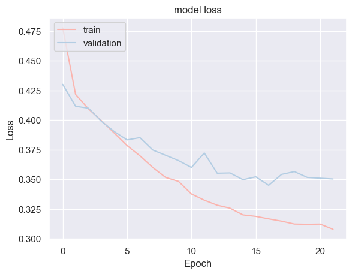

```python
# Plotting Train Loss vs Validation Loss
plt.plot(history_es.history["loss"])
plt.plot(history_es.history["val_loss"])
plt.title("model loss")
plt.ylabel("Loss")
plt.xlabel("Epoch")
plt.legend(["train", "validation"], loc="upper left")
plt.show()
```

**Let's tune the threshold using ROC-AUC**

```
Best Threshold=0.219631, G-Mean=0.815
```

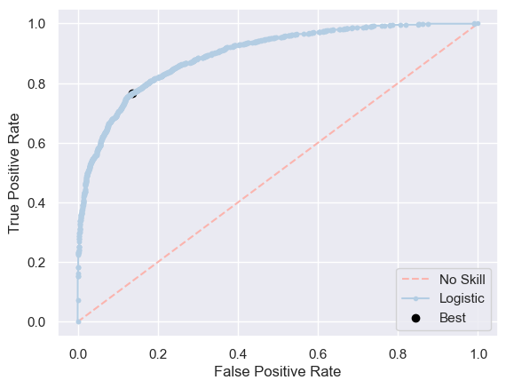

```python
# predict probabilities
yhat = model_es.predict(X_train)
# keep probabilities for the positive outcome only
yhat = yhat[:, 0]
# calculate roc curves
fpr, tpr, thresholds = roc_curve(y_train, yhat)
# calculate the g-mean for each threshold
gmeans = np.sqrt(tpr * (1 - fpr))
# locate the index of the largest g-mean
ix = np.argmax(gmeans)
print("Best Threshold=%f, G-Mean=%.3f" % (thresholds[ix], gmeans[ix]))
# plot the roc curve for the model
pyplot.plot([0, 1], [0, 1], linestyle="--", label="No Skill")
pyplot.plot(fpr, tpr, marker=".", label="Logistic")
pyplot.scatter(fpr[ix], tpr[ix], marker="o", color="black", label="Best")
# axis labels
pyplot.xlabel("False Positive Rate")
pyplot.ylabel("True Positive Rate")
pyplot.legend()
# show the plot
pyplot.show()
```

**Predict the results using the best threshold**

```python
# Predicting the results using best as a threshold
y_pred_es = model_es.predict(X_val)
y_pred_es = y_pred_es > thresholds[ix]
y_pred_es
```

```
array([[False],
       [ True],
       [False],
       ...,
       [ True],
       [ True],
       [False]])
```

**Classification report**

```python
## Obtain the classification report Hint: use y_val
cr = metrics.classification_report(y_val, y_pred_es)
print(cr)
```

```
              precision    recall  f1-score   support

           0       0.91      0.84      0.87      1274
           1       0.52      0.67      0.58       326

    accuracy                           0.81      1600
   macro avg       0.71      0.76      0.73      1600
weighted avg       0.83      0.81      0.81      1600
```

**Confusion matrix**

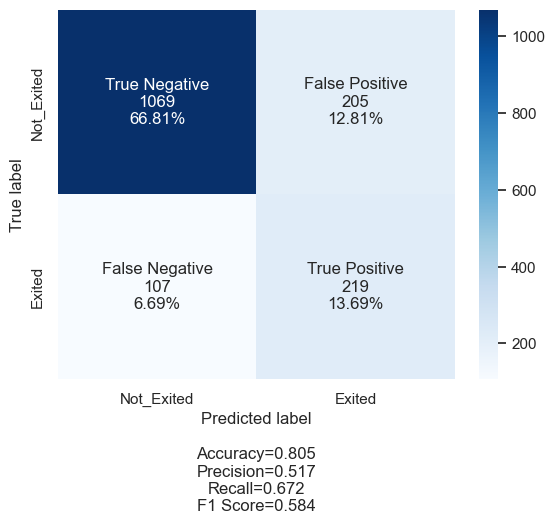

```python
## Complete the code with y_val and y_pred_es to plot the confusion matrix

cm1 = confusion_matrix(y_val, y_pred_es)
labels = ["True Negative", "False Positive", "False Negative", "True Positive"]
categories = ["Not_Exited", "Exited"]
make_confusion_matrix(cm1, group_names=labels, categories=categories, cmap="Blues")
```

### Model Improvement: Neural Network model with Dropout

```python
backend.clear_session()
# Fixing the seed for random number generators so that we can ensure we receive the same output everytime
np.random.seed(1)
random.seed(1)
tf.random.set_seed(1)
```

```python
# Initializing the neural network
model3 = Sequential()

# Adding 32 neurons and relu as activation function
model3.add(Dense(32, activation="relu", input_dim=14))

# Add dropout with dropout_rate= 0.2
model3.add(Dropout(0.2))

# Adding hidden layer with 16 neurons with relu as activation functions
model3.add(Dense(16, activation="relu"))

# Adding dropout with dropout_rate= 0.1
model3.add(Dropout(0.1))

# Adding hidden layer with 8 neurons with relu as activation functions
model3.add(Dense(8, activation="relu"))

# Adding the output layer
model3.add(Dense(1, activation="sigmoid"))
```

```python
# Summary of the model
model3.summary()
```

```
Model: "sequential"
_________________________________________________________________
 Layer (type)                Output Shape              Param #
=================================================================
 dense (Dense)               (None, 32)                480

 dropout (Dropout)           (None, 32)                0

 dense_1 (Dense)             (None, 16)                528

 dropout_1 (Dropout)         (None, 16)                0

 dense_2 (Dense)             (None, 8)                 136

 dense_3 (Dense)             (None, 1)                 9

=================================================================
Total params: 1,153
Trainable params: 1,153
Non-trainable params: 0
_________________________________________________________________
```

```python
# Initialize the ANN with Adam optimizer
opt = tf.keras.optimizers.Adam(0.001)

# Compiling the model with binary cross entropy as loss function and accuracy as metrics
model3.compile(loss="binary_crossentropy", optimizer=opt, metrics=["accuracy"])
```

```python
# Fitting the ANN (combining early stopping with dropout)
history3 = model3.fit(
    X_train,
    y_train,
    batch_size=32,
    epochs=100,
    verbose=1,
    validation_data=(X_val, y_val),
    callbacks=[es_cb],
)
```

**Loss function**

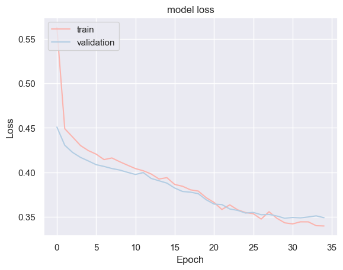

```python
# Code to plot the Train Loss and Validation Loss
plt.plot(history3.history["loss"])
plt.plot(history3.history["val_loss"])
plt.title("model loss")
plt.ylabel("Loss")
plt.xlabel("Epoch")
plt.legend(["train", "validation"], loc="upper left")
plt.show()
```

```
Best Threshold=0.174122, G-Mean=0.797
```

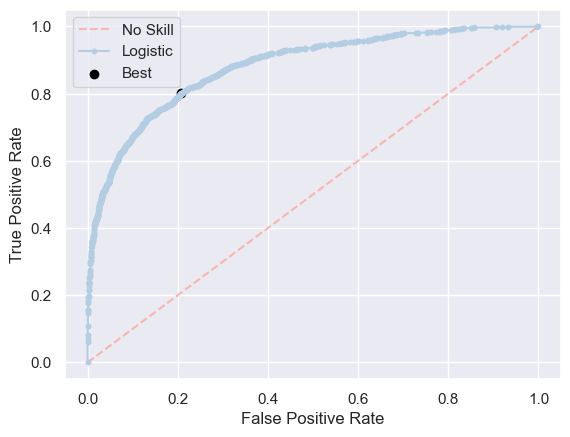

```python
# predict probabilities
yhat = model3.predict(X_train)
# keep probabilities for the positive outcome only
yhat = yhat[:, 0]
# calculate roc curves
fpr, tpr, thresholds = roc_curve(y_train, yhat)
# calculate the g-mean for each threshold
gmeans = np.sqrt(tpr * (1 - fpr))
# locate the index of the largest g-mean
ix = np.argmax(gmeans)
print("Best Threshold=%f, G-Mean=%.3f" % (thresholds[ix], gmeans[ix]))
# plot the roc curve for the model
pyplot.plot([0, 1], [0, 1], linestyle="--", label="No Skill")
pyplot.plot(fpr, tpr, marker=".", label="Logistic")
pyplot.scatter(fpr[ix], tpr[ix], marker="o", color="black", label="Best")
# axis labels
pyplot.xlabel("False Positive Rate")
pyplot.ylabel("True Positive Rate")
pyplot.legend()
# show the plot
pyplot.show()
```

**Predict the results using the best threshold**

```python
# Predicting the results using best as a threshold
y_pred_es_do = model3.predict(X_val)
y_pred_3 = y_pred_es_do > thresholds[ix]
y_pred_3
```

```
array([[False],
       [ True],
       [ True],
       ...,
       [ True],
       [ True],
       [False]])
```

**Classification report**

```python
# Complete the code to obtain the classification report
cr = metrics.classification_report(y_val, y_pred_3)
print(cr)
```

```
              precision    recall  f1-score   support

           0       0.92      0.79      0.85      1274
           1       0.48      0.75      0.58       326

    accuracy                           0.78      1600
   macro avg       0.70      0.77      0.72      1600
weighted avg       0.83      0.78      0.80      1600
```

**Confusion report**

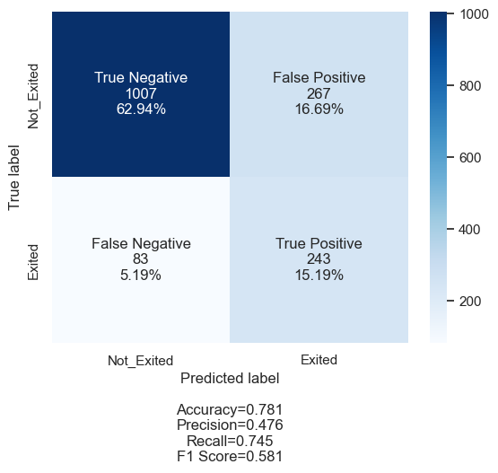

```python
# Complete the code to obtain the confusion matrix

cm1 = confusion_matrix(y_val, y_pred_3)
labels = ["True Negative", "False Positive", "False Negative", "True Positive"]
categories = ["Not_Exited", "Exited"]
make_confusion_matrix(cm1, group_names=labels, categories=categories, cmap="Blues")
```

### Model Improvement: Neural Network model with Hyperparameter tuning

```python
backend.clear_session()
# Fixing the seed for random number generators so that we can ensure we receive the same output everytime
np.random.seed(1)
random.seed(1)
tf.random.set_seed(1)
```

```python
def create_model_v2(dropout_rate=0.1, lr=0.001, layer_1=64, layer_2=32):
    np.random.seed(1)

    # Initializing the neural network
    model = Sequential()

    # This adds the input layer (by specifying input dimension)
    model.add(Dense(layer_1, activation="relu", input_dim=X_train.shape[1]))

    ## Complete the code by adding dropout with dropout rate=0.5
    model.add(Dropout(0.5))

    # # Adding the hidden layer
    # Notice that we do not need to specify input dim.
    model.add(Dense(layer_2, activation="relu"))

    # # Adding the output layer
    # Notice that we do not need to specify input dim.
    # we have an output of 1 node, which is the the desired dimensions of our output (stay with the bank or not)
    # We use the sigmoid because we want probability outcomes
    model.add(Dense(1, activation="sigmoid"))

    # Adding Adam initializer
    optimizer = tf.keras.optimizers.Adam(learning_rate=lr)

    ## Complete the code to compile the model using binary_crossentropy as loss
    model.compile(optimizer=optimizer, loss="binary_crossentropy", metrics=["accuracy"])
    return model
```

**Using Grid search**

```python
## Complete the code by calling the creat_model_v2 function in KerasClassifier
keras_estimator = KerasClassifier(build_fn=create_model_v2, verbose=1)
```

```python
# define the grid search parameters
param_grid = {"batch_size": [40, 64, 128], "lr": [0.01, 0.001, 0.1]}


kfold_splits = 3
# Using the the defined keras_estimator as estimator.
grid = GridSearchCV(
    estimator=keras_estimator,
    verbose=1,
    cv=kfold_splits,
    param_grid=param_grid,
    n_jobs=-1,
)
```

```python
## Complete the code to fit the model on train data and use x_val and y_val as validation data
grid_result = grid.fit(X_train, y_train, validation_data=(X_val, y_val), verbose=1)

# Summarize results
print("Best: %f using %s" % (grid_result.best_score_, grid_result.best_params_))
# Printing mean
means = grid_result.cv_results_["mean_test_score"]
# Printing standard deviation
stds = grid_result.cv_results_["std_test_score"]
# Printing best parameters
params = grid_result.cv_results_["params"]
```

```
Fitting 3 folds for each of 9 candidates, totalling 27 fits
Best: 0.815312 using {'batch_size': 40, 'lr': 0.01}
```

**Let's create the final model with the obtained configuration after hyperparameter tuning**

```python
# Creating the model
model4 = create_model_v2(lr=grid_result.best_params_["lr"])
# Printing model summary
model4.summary()
```

```
Model: "sequential_1"
_________________________________________________________________
 Layer (type)                Output Shape              Param #
=================================================================
 dense_3 (Dense)             (None, 64)                960

 dropout_1 (Dropout)         (None, 64)                0

 dense_4 (Dense)             (None, 32)                2080

 dense_5 (Dense)             (None, 1)                 33

=================================================================
Total params: 3,073
Trainable params: 3,073
Non-trainable params: 0
_________________________________________________________________
```

```python
## Complete the code to fit the model on train data abd train the model with best batch_size obtained from hyperparameter tuning
history4=model4.fit(X_train, y_train, epochs=100, batch_size = grid_result.best_params_['batch_size'], verbose=1,validation_data=(X_val,y_val))
```

**Loss function**

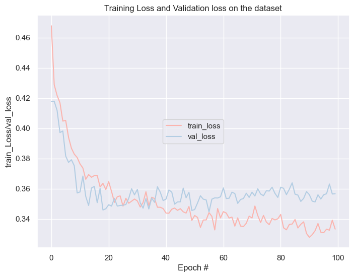

```python
N = 100
plt.figure(figsize=(8, 6))
plt.plot(np.arange(0, N), history4.history["loss"], label="train_loss")
plt.plot(np.arange(0, N), history4.history["val_loss"], label="val_loss")

plt.title("Training Loss and Validation loss on the dataset")
plt.xlabel("Epoch #")
plt.ylabel("train_Loss/val_loss")
plt.legend(loc="center")
plt.show()
```

**Threshold**

```
Best Threshold=0.172328, G-Mean=0.800
```

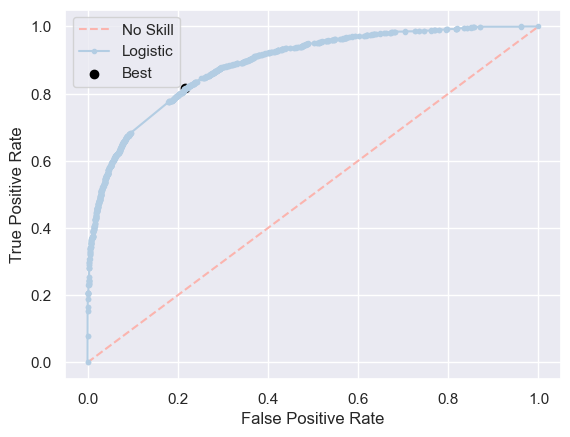

```python
# predict probabilities
yhat = model4.predict(X_train)
# keep probabilities for the positive outcome only
yhat = yhat[:, 0]
# calculate roc curves
fpr, tpr, thresholds = roc_curve(y_train, yhat)
# calculate the g-mean for each threshold
gmeans = np.sqrt(tpr * (1 - fpr))
# locate the index of the largest g-mean
ix = np.argmax(gmeans)
print("Best Threshold=%f, G-Mean=%.3f" % (thresholds[ix], gmeans[ix]))
# plot the roc curve for the model
pyplot.plot([0, 1], [0, 1], linestyle="--", label="No Skill")
pyplot.plot(fpr, tpr, marker=".", label="Logistic")
pyplot.scatter(fpr[ix], tpr[ix], marker="o", color="black", label="Best")
# axis labels
pyplot.xlabel("False Positive Rate")
pyplot.ylabel("True Positive Rate")
pyplot.legend()
# show the plot
pyplot.show()
```

**Predict the results using the best threshold**

```python
# Obtain the predictions on X_val
y_pred_4 = model4.predict(X_val)
print(y_pred_4)
```

```
[[0.0576676 ]
 [0.46673593]
 [0.0364369 ]
 ...
 [0.5230996 ]
 [0.35036245]
 [0.14188226]]
```

```python
# To use the confusion Matrix, we need to convert the probabilities into Yes or No.
# We will use the best cutoff value  to indicate whether they are likely to exit or not.
y_pred_4 = y_pred_4 > thresholds[ix]
print(y_pred_4)
```

```
[[False]
 [ True]
 [False]
 ...
 [ True]
 [ True]
 [False]]
```

**Classification report**

```python
# Complete the code to obtain the classification report
cr = metrics.classification_report(y_val, y_pred_4)
print(cr)
```

```
              precision    recall  f1-score   support

           0       0.93      0.77      0.84      1274
           1       0.46      0.76      0.58       326

    accuracy                           0.77      1600
   macro avg       0.70      0.77      0.71      1600
weighted avg       0.83      0.77      0.79      1600
```

**Confusion matrix**

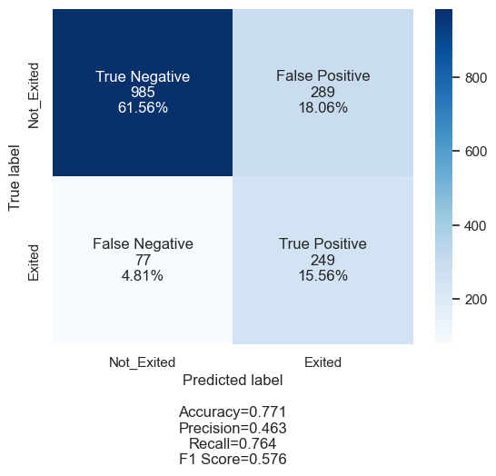

```python
## Obtain the confusion matrix
cm_h = confusion_matrix(y_val, y_pred_4)

labels = ["True Negative", "False Positive", "False Negative", "True Positive"]
categories = ["Not_Exited", "Exited"]
make_confusion_matrix(cm_h, group_names=labels, categories=categories, cmap="Blues")
```

```python
## Complete the code to apply SMOTE on train data
sm = SMOTE(random_state=1)
X_train_up, y_train_up = sm.fit_resample(X_train, y_train)
print("Before UpSampling, the shape of X_train: {}".format(X_train.shape))
print("Before UpSampling, the shape of X_train: {} \n".format(y_train.shape))
print("After UpSampling, the shape of X_train_up: {}".format(X_train_up.shape))
print("After UpSampling, the shape of X_train_up: {} \n".format(y_train_up.shape))
```

```
Before UpSampling, the shape of X_train: (6400, 14)
Before UpSampling, the shape of X_train: (6400, 1)

After UpSampling, the shape of X_train_up: (10192, 14)
After UpSampling, the shape of X_train_up: (10192, 1)
```

```python
backend.clear_session()
# Fixing the seed for random number generators so that we can ensure we receive the same output everytime
np.random.seed(2)
random.seed(2)
tf.random.set_seed(2)
```

```python
## Initilaize a sequential model
model5 = Sequential()

# Input layer of 32 neurons with relu as activation function
model5.add(Dense(32, activation="relu", input_dim=X_train.shape[1]))

# Add dropout with dropout rate=0.2
model5.add(Dropout(0.2))

# Hidden layer with 16 neurons with relu as activation function
model5.add(Dense(16, activation="relu"))

# Add dropout with dropout rate=0.1
model5.add(Dropout(0.1))

## Add dense layers with 8 neurons
model5.add(Dense(8, activation="relu"))

# Adding Sigmoid activation function in the final layer
model5.add(Dense(1, activation="sigmoid"))
```

```python
## Complete the code to obtain the summary of the model
model5.summary()
```

```
Model: "sequential"
_________________________________________________________________
 Layer (type)                Output Shape              Param #
=================================================================
 dense (Dense)               (None, 32)                480

 dropout (Dropout)           (None, 32)                0

 dense_1 (Dense)             (None, 16)                528

 dropout_1 (Dropout)         (None, 16)                0

 dense_2 (Dense)             (None, 8)                 136

 dense_3 (Dense)             (None, 1)                 9

=================================================================
Total params: 1,153
Trainable params: 1,153
Non-trainable params: 0
_________________________________________________________________
```

```python
# Define earlystopping as callback
es_cb = callbacks.EarlyStopping(monitor="val_loss", min_delta=0.001, patience=5)

# Initializing Adam optimizer
opt = tf.keras.optimizers.Adam(0.001)

# Compile the model with binary cross entropy as loss and accuracy as metrics
model5.compile(optimizer=opt, loss="binary_crossentropy", metrics=["accuracy"])

# Complete the code to fit the model on train with batch_size of 64, epochs of 100 and callbacks as earlystopping
history5 = model5.fit(
    X_train,
    y_train,
    batch_size=64,
    epochs=100,
    verbose=1,
    validation_data=(X_val, y_val),
    callbacks=[es_cb],
)
```

**Loss function**

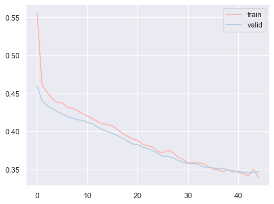

```python
# Capturing learning history per epoch
hist = pd.DataFrame(history5.history)
hist["epoch"] = history5.epoch

# Plotting accuracy at different epochs
plt.plot(hist["loss"])
plt.plot(hist["val_loss"])
plt.legend(("train", "valid"), loc=0)
```

**Finding the optimal threshold**

```
Best Threshold=0.222061, G-Mean=0.794
```

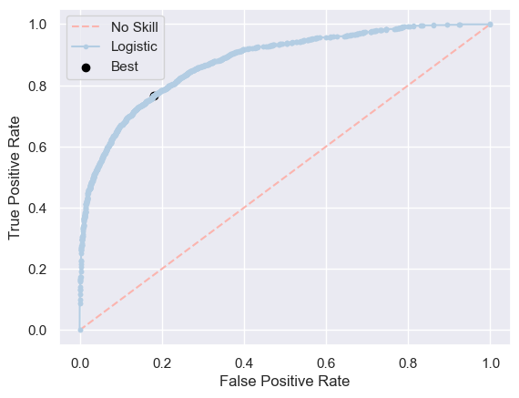

```python
## Find the optimal threshold using X_train
yhat = model5.predict(X_train)

# keep probabilities for the positive outcome only
yhat = yhat[:, 0]
# calculate roc curves
fpr, tpr, thresholds = roc_curve(y_train, yhat)
# calculate the g-mean for each threshold
gmeans = np.sqrt(tpr * (1 - fpr))
# locate the index of the largest g-mean
ix = np.argmax(gmeans)
print("Best Threshold=%f, G-Mean=%.3f" % (thresholds[ix], gmeans[ix]))
# plot the roc curve for the model
pyplot.plot([0, 1], [0, 1], linestyle="--", label="No Skill")
pyplot.plot(fpr, tpr, marker=".", label="Logistic")
pyplot.scatter(fpr[ix], tpr[ix], marker="o", color="black", label="Best")
# axis labels
pyplot.xlabel("False Positive Rate")
pyplot.ylabel("True Positive Rate")
pyplot.legend()
# show the plot
pyplot.show()
```

```python
## Obtain the predictions on X_val
y_pred_s = model5.predict(X_val)
# Predicting the results using tuned threshold
y_pred_s = y_pred_s > thresholds[ix]
y_pred_s
```

```
array([[False],
       [ True],
       [False],
       ...,
       [ True],
       [ True],
       [False]])
```

**Classification report**

```python
cr = metrics.classification_report(y_val, y_pred_s)
print(cr)
```

```
              precision    recall  f1-score   support

           0       0.92      0.82      0.87      1274
           1       0.51      0.73      0.60       326

    accuracy                           0.80      1600
   macro avg       0.72      0.78      0.73      1600
weighted avg       0.84      0.80      0.81      1600
```

**Confusion matrix**

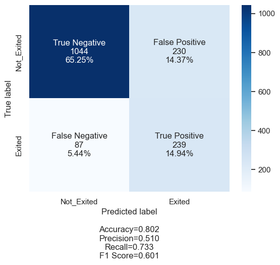

```python
# Calculating the confusion matrix
cm_s = confusion_matrix(y_val, y_pred_s)
labels = ["True Negative", "False Positive", "False Negative", "True Positive"]
categories = ["Not_Exited", "Exited"]
make_confusion_matrix(cm_s, group_names=labels, categories=categories, cmap="Blues")
```

## Final Model

Comparing all the models, our best model is using the best parameters from the Neural Network model with Hyperparameter tuning: Model 4.

```
Best Threshold=0.172328, G-Mean=0.800
```

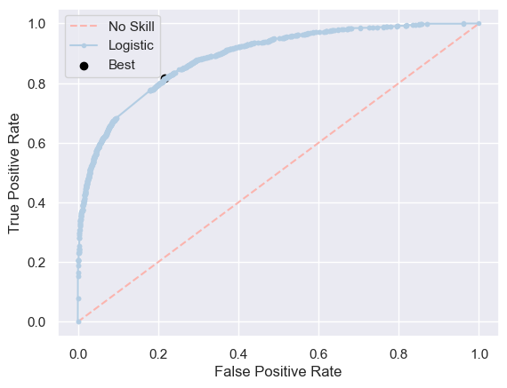

```python
# predict probabilities using the best model
yhat = model4.predict(X_train)
# keep probabilities for the positive outcome only
yhat = yhat[:, 0]
# calculate roc curves
fpr, tpr, thresholds = roc_curve(y_train, yhat)
# calculate the g-mean for each threshold
gmeans = np.sqrt(tpr * (1 - fpr))
# locate the index of the largest g-mean
ix = np.argmax(gmeans)
print("Best Threshold=%f, G-Mean=%.3f" % (thresholds[ix], gmeans[ix]))
# plot the roc curve for the model
pyplot.plot([0, 1], [0, 1], linestyle="--", label="No Skill")
pyplot.plot(fpr, tpr, marker=".", label="Logistic")
pyplot.scatter(fpr[ix], tpr[ix], marker="o", color="black", label="Best")
# axis labels
pyplot.xlabel("False Positive Rate")
pyplot.ylabel("True Positive Rate")
pyplot.legend()
# show the plot
pyplot.show()
```

```python
# Complete the code to Predict the X_test data using the best model
y_pred_test = model4.predict(X_test)
y_pred_test = y_pred_test > thresholds[ix]
print(y_pred_test)
```

```
[[False]
 [False]
 [False]
 ...
 [ True]
 [False]
 [False]]
```

**Classification report**

```python
## Complete the code to obtain the classification report on y_test and the predicted values
cr = metrics.classification_report(y_test, y_pred_test)
print(cr)
```

```
              precision    recall  f1-score   support

           0       0.92      0.76      0.83      1593
           1       0.44      0.73      0.55       407

    accuracy                           0.76      2000
   macro avg       0.68      0.75      0.69      2000
weighted avg       0.82      0.76      0.78      2000
```

**Confusion report**

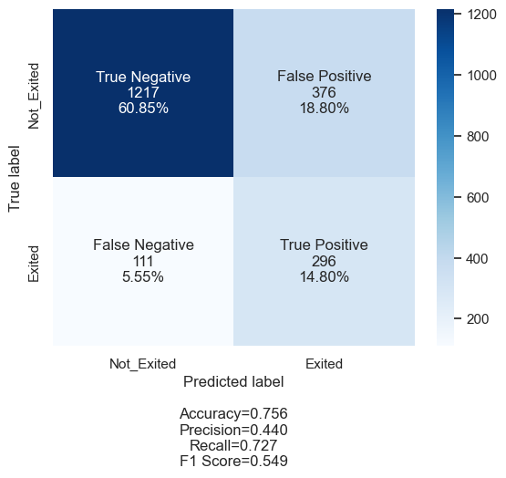

```python
# Complete the code to obtain the confusion matrix
cm_h = confusion_matrix(y_test, y_pred_test)
labels = ["True Negative", "False Positive", "False Negative", "True Positive"]
categories = ["Not_Exited", "Exited"]
make_confusion_matrix(cm_h, group_names=labels, categories=categories, cmap="Blues")
```

## Actionable Insights and Business Recommendations

## *Key Insights from EDA*

From the Exploratory Data Analysis done, the following observations and key insights became evident:

1. *Almost 50% of the customers are inactive. The Bank should come up with innovative ideas that will add value to the Customers and encourage customer activities.*
1. *About 32% of Germans customers Exited. This is twice as many compared to customers from France and Spain.*
2. *Older Customers should be targeted for more retention.*

## *Key Insights from the BEST Model*

From our BEST of of several models, model is using the best parameters from the Neural Network model with Hyperparameter tuning, the following observations and key insights became evident:

1. *From a business perspective, Recall is the best measure for the desired Predictive Model. The model gives us Best RECALL Score of 0.764 (76.4%).*

## **Further Analysis and Modeling:**

1. *It is hereby recommended that further data collection should be done to capture additional information like the duration of inactivity. It is not enough to know the inactive Customers, it will really help decision making and model building to know the duration of inactivity.*
2. *The data collection process can be enhanced to capture additional information related to Customer Employment, Living Status and Spending Pattern.*